# Data analysis, the data.table way

## Example: COVID-19 Pandemic in the US

Using basic exploratory analyses to:

1. Plot the trend for number of total and new cases in Coconino county and the state of Arizona and the US,
2. Show which counties and which states have passed their COVID-19 peak.
3. Determine which counties and states have the highest number of cases per population.

**Hint I**: You can obtain the main dataset containing number of COVID-19 cases in the US from [this link](https://raw.githubusercontent.com/CSSEGISandData/COVID-19/master/csse_covid_19_data/csse_covid_19_time_series/time_series_covid19_confirmed_US.csv).

**Hint II**: You can obtain counties populaiton data from [this link](https://data.nber.org/census/popest/county_population.csv).

```r
library(data.table)

#download covid data
covid19_url <- 'https://raw.githubusercontent.com/CSSEGISandData/COVID-19/master/csse_covid_19_data/csse_covid_19_time_series/time_series_covid19_confirmed_US.csv'

# create an temporary file path to save the file
covid19_file <- tempfile(fileext = '.csv', pattern = basename(covid19_url))

#download the file
download.file(url = covid19_url, destfile = covid19_file)

#load the file as a
covid <- fread(covid19_file)
# covid

#reorganizing the data from columns to rows
covid <- melt(covid, id.vars = 1:11, variable.name = 'date', value.name = 'count')
covid
```

```
##              UID iso2 iso3 code3 FIPS         Admin2
##      1:       16   AS  ASM    16   60
##      2:      316   GU  GUM   316   66
##      3:      580   MP  MNP   580   69
##      4:      630   PR  PRI   630   72
##      5:      850   VI  VIR   850   78
##     ---
## 332618: 84070016   US  USA   840   NA   Central Utah
## 332619: 84070017   US  USA   840   NA Southeast Utah
## 332620: 84070018   US  USA   840   NA Southwest Utah
## 332621: 84070019   US  USA   840   NA      TriCounty
## 332622: 84070020   US  USA   840   NA   Weber-Morgan
##                   Province_State Country_Region       Lat     Long_
##      1:           American Samoa             US -14.27100 -170.1320
##      2:                     Guam             US  13.44430  144.7937
```

[output cut: 21 more lines]

```r
#converting the date format
covid[, Date := as.Date(date, format = '%m/%d/%y')]
covid$date <- NULL

colnames(covid)
```

```
##  [1] "UID"            "iso2"           "iso3"           "code3"
##  [5] "FIPS"           "Admin2"         "Province_State" "Country_Region"
##  [9] "Lat"            "Long_"          "Combined_Key"   "count"
## [13] "Date"
```

```r
str(covid)
```

```
## Classes 'data.table' and 'data.frame':   332622 obs. of  13 variables:
##  $ UID           : num  16 316 580 630 850 ...
##  $ iso2          : chr  "AS" "GU" "MP" "PR" ...
##  $ iso3          : chr  "ASM" "GUM" "MNP" "PRI" ...
##  $ code3         : int  16 316 580 630 850 840 840 840 840 840 ...
##  $ FIPS          : num  60 66 69 72 78 ...
##  $ Admin2        : chr  "" "" "" "" ...
##  $ Province_State: chr  "American Samoa" "Guam" "Northern Mariana Islands" "Puerto Rico" ...
##  $ Country_Region: chr  "US" "US" "US" "US" ...
##  $ Lat           : num  -14.3 13.4 15.1 18.2 18.3 ...
##  $ Long_         : num  -170.1 144.8 145.7 -66.6 -64.9 ...
##  $ Combined_Key  : chr  "American Samoa, US" "Guam, US" "Northern Mariana Islands, US" "Puerto Rico, US" ...
##  $ count         : int  0 0 0 0 0 0 0 0 0 0 ...
##  $ Date          : Date, format: "2020-01-22" "2020-01-22" ...
##  - attr(*, ".internal.selfref")=<externalptr>
```

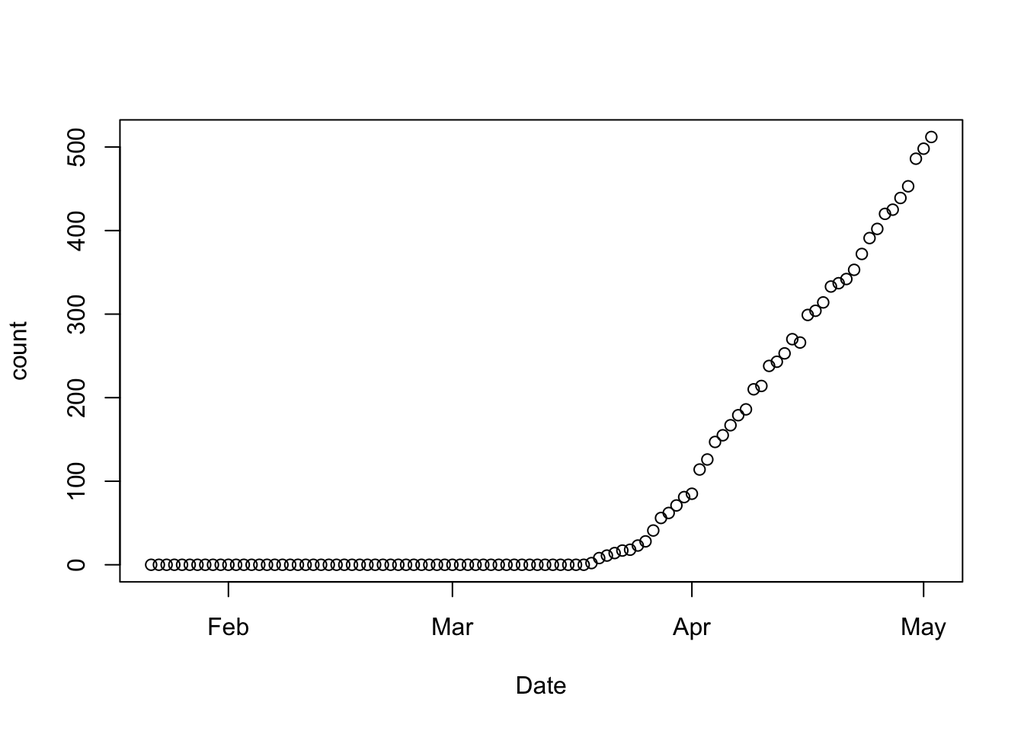

```r
#plot covid cases in Coconino county, AZ
covid[Combined_Key == 'Coconino, Arizona, US', plot(Date, count)]
```

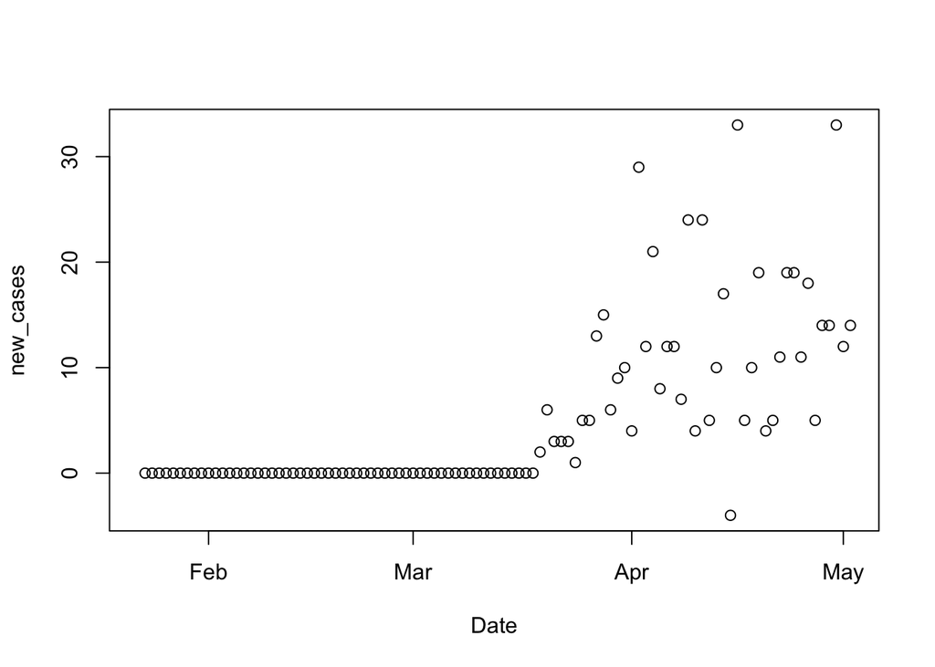

```r
#define a colujmn for New Cases
covid[, new_cases := c(NA, diff(count)), Combined_Key]
covid[Combined_Key == 'Coconino, Arizona, US', plot(Date, new_cases)]
```

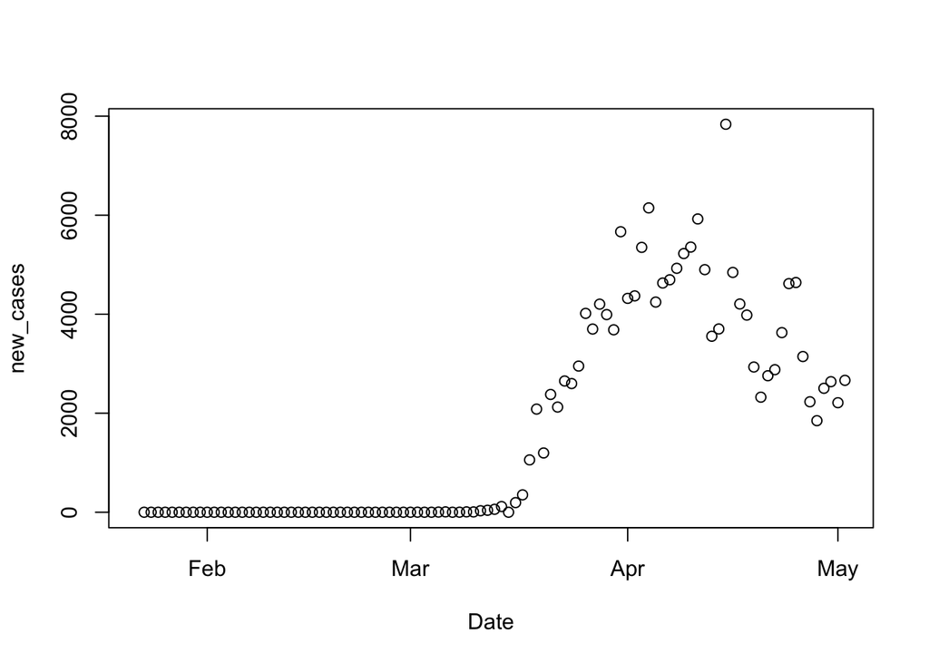

```r
#plot covid cases in New York City
covid[Combined_Key == 'New York City, New York, US', plot(Date, new_cases)]
```

```r
#group by Combined_Key
covid[, max_new_cases := max(new_cases, na.rm = TRUE), Combined_Key]

#show most recent data
covid[Date==Sys.Date()-1, ]
```

```
##            UID iso2 iso3 code3 FIPS         Admin2
##    1:       16   AS  ASM    16   60
##    2:      316   GU  GUM   316   66
##    3:      580   MP  MNP   580   69
##    4:      630   PR  PRI   630   72
##    5:      850   VI  VIR   850   78
##   ---
## 3257: 84070016   US  USA   840   NA   Central Utah
## 3258: 84070017   US  USA   840   NA Southeast Utah
## 3259: 84070018   US  USA   840   NA Southwest Utah
## 3260: 84070019   US  USA   840   NA      TriCounty
## 3261: 84070020   US  USA   840   NA   Weber-Morgan
##                 Province_State Country_Region       Lat     Long_
##    1:           American Samoa             US -14.27100 -170.1320
##    2:                     Guam             US  13.44430  144.7937
```

[output cut: 33 more lines]

```r
# print the names of the counties where number of cases is smaller than the maximum for that county
covid[(Date==Sys.Date()-1) & new_cases < max_new_cases, .(Combined_Key)]
```

```
##                       Combined_Key
##    1:                     Guam, US
##    2: Northern Mariana Islands, US
##    3:           Virgin Islands, US
##    4:         Autauga, Alabama, US
##    5:         Baldwin, Alabama, US
##   ---
## 2714:       Central Utah, Utah, US
## 2715:     Southeast Utah, Utah, US
## 2716:     Southwest Utah, Utah, US
## 2717:          TriCounty, Utah, US
## 2718:       Weber-Morgan, Utah, US
```

```r
#create a new table for states
covid_states <- covid[Province_State%in%state.name,
                      .(state_new_cases = sum(new_cases)),
                      .(State = Province_State, Date)]
covid_states
```

```
##               State       Date state_new_cases
##    1:       Alabama 2020-01-22              NA
##    2:        Alaska 2020-01-22              NA
##    3:       Arizona 2020-01-22              NA
##    4:      Arkansas 2020-01-22              NA
##    5:    California 2020-01-22              NA
##   ---
## 5096:      Virginia 2020-05-02             836
## 5097:    Washington 2020-05-02             366
## 5098: West Virginia 2020-05-02              33
## 5099:     Wisconsin 2020-05-02             346
## 5100:       Wyoming 2020-05-02              13
```

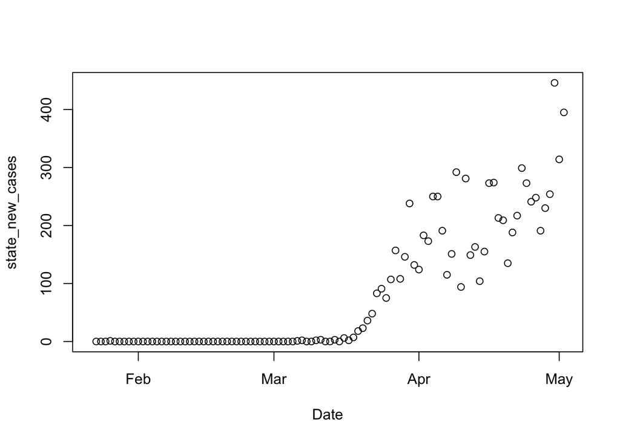

```r
#plot Arizona cases
covid_states[State=='Arizona', plot(Date, state_new_cases)]
```

```r
# find maximum for each state
covid_states[, state_max := max(state_new_cases, na.rm = TRUE), State]

# when state's peak occured and sort states names by the peak's date
covid_states[state_new_cases==state_max,
             .(state_max_date = min(Date)),
             State][order(state_max_date)]
```

```
##              State state_max_date
##  1:         Alaska     2020-03-28
##  2:        Florida     2020-04-02
##  3:          Idaho     2020-04-02
##  4:      Louisiana     2020-04-02
##  5:          Maine     2020-04-02
##  6:        Montana     2020-04-02
##  7:     Washington     2020-04-02
##  8:         Hawaii     2020-04-03
##  9:       Michigan     2020-04-03
## 10:     New Jersey     2020-04-03
## 11:       Oklahoma     2020-04-04
## 12:        Vermont     2020-04-04
## 13:         Oregon     2020-04-05
## 14: South Carolina     2020-04-09
```

[output cut: 37 more lines]

```r
# print the names of the states where number of cases is larger than the maximum for that state
covid_states[(Date==Sys.Date()-1)&state_new_cases>=state_max, .(State, state_new_cases)]
```

```
##    State state_new_cases
## 1:  Iowa             759
```

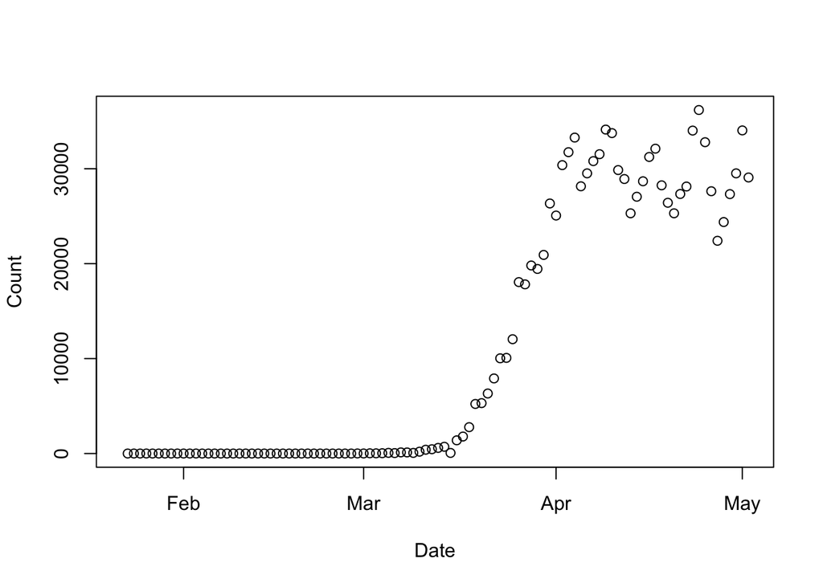

```r
#plot the trend for the country
covid_usa <- covid[, .(Count = sum(new_cases)), .(Date)]

covid_usa[, plot(Date, Count)]
```

## Combine with the population data

We need to download the population data and merge it with the Covid-19 data. However, this is tricky as we need a common column with matching values between the two tables. We can use the `Combined_Key` column from the `covid` and try to make a similar column in the population table that we are going to download.

```r
ppl_url <- 'https://data.nber.org/census/popest/county_population.csv'

# create an temporary file path to save the file
ppl_file <- tempfile(fileext = '.csv', pattern = basename(ppl_url))

#download the file
download.file(url = ppl_url, destfile = ppl_file)

#load the file as a
ppl <- fread(ppl_file)

#remove extra data and reorganize
colnames(ppl)
```

```
##  [1] "fips"        "state_fips"  "county_fips" "areaname"    "state_name"
##  [6] "county_name" "fipsst"      "fipsco"      "region"      "division"
## [11] "pop1970"     "pop1971"     "pop1972"     "pop1973"     "pop1974"
## [16] "pop1975"     "pop1976"     "pop1977"     "pop1978"     "pop1979"
## [21] "pop1980"     "pop1981"     "pop1982"     "pop1983"     "pop1984"
## [26] "pop1985"     "pop1986"     "pop1987"     "pop1988"     "pop1989"
## [31] "pop1990"     "pop1991"     "pop1992"     "pop1993"     "pop1994"
## [36] "pop1995"     "pop1996"     "pop1997"     "pop1998"     "pop1999"
## [41] "pop2000"     "pop2001"     "pop2002"     "pop2003"     "pop2004"
## [46] "pop2005"     "pop2006"     "pop2007"     "pop2008"     "pop2009"
## [51] "pop19904"    "pop20104"    "base20104"   "pop2010"     "pop2011"
## [56] "pop2012"     "pop2013"     "pop2014"
```

```r
ppl_counties <- ppl[grepl(areaname, pattern = 'County') & county_fips > 1000,
                    .(county_name,
                      state_name,
                      population = pop2014)]
ppl_counties[, area := paste0( gsub(county_name, pattern = ' County', replacement = ','), state_name, ', US')]
```

Now, we can merge the two datasets using the `area` column in `ppl_counties` and the `Combined_Key` column in `covid`. There might be few missing rows between the two, but for the purpose of this workshop, that is fine:

```r
covid_ppl <- merge(covid[, .(Combined_Key, Date, covid.counts = count)],
                   ppl_counties[, .(area,
                                    state = state_name,
                                    population)], by.x = 'Combined_Key', by.y = 'area')

# caclulate per population cases and put it in a new table
per_ppl <- covid_ppl[Date==Sys.Date() - 1, .( area = Combined_Key,
                                              state,
                                              cases_per_million = covid.counts / population * 1e6)]

# top 20
per_ppl[order(-cases_per_million)][1:20]
```

```
##                          area       state cases_per_million
##  1:  Trousdale, Tennessee, US   Tennessee         167958.01
##  2:     Lincoln, Arkansas, US    Arkansas          58482.46
##  3:      Dakota, Nebraska, US    Nebraska          45179.86
##  4:    Bledsoe, Tennessee, US   Tennessee          42782.28
##  5:     Nobles, Minnesota, US   Minnesota          41639.65
##  6:    Rockland, New York, US    New York          36882.54
##  7:          Marion, Ohio, US        Ohio          34905.66
##  8:         Cass, Indiana, US     Indiana          31843.49
##  9: Westchester, New York, US    New York          30459.56
## 10:        Pickaway, Ohio, US        Ohio          30311.55
## 11:      Nassau, New York, US    New York          26879.34
## 12:   Passaic, New Jersey, US  New Jersey          25708.65
## 13:          Louisa, Iowa, US        Iowa          24818.56
## 14:      Orange, New York, US    New York          23690.57
## 15:     Union, New Jersey, US  New Jersey          23503.50
## 16:         Blaine, Idaho, US       Idaho          23135.65
## 17:    Hudson, New Jersey, US  New Jersey          23016.97
## 18:        Seward, Kansas, US      Kansas          22970.38
## 19:     Suffolk, New York, US    New York          22939.94
## 20:     Randolph, Georgia, US     Georgia          22289.07
```

```r
# areas with zero number of cases
per_ppl[cases_per_million == 0, .(area, state)][order(state)]
```

```
##                            area       state
##   1:      Calhoun, Arkansas, US    Arkansas
##   2: Little River, Arkansas, US    Arkansas
##   3:     Lassen, California, US  California
##   4:      Modoc, California, US  California
##   5:     Sierra, California, US  California
##  ---
## 296:    Langlade, Wisconsin, US   Wisconsin
## 297:       Pepin, Wisconsin, US   Wisconsin
## 298:      Taylor, Wisconsin, US   Wisconsin
## 299:        Platte, Wyoming, US     Wyoming
## 300:        Weston, Wyoming, US     Wyoming
```

## More on `data.tables`:

- [R For Data Science Cheat Sheet](https://s3.amazonaws.com/assets.datacamp.com/blog_assets/datatable_Cheat_Sheet_R.pdf)
- [Data Transformation with data.table](https://www.beoptimized.be/pdf/R_Data_Transformation.pdf)
- Interactive course: [Data Analysis in R, the data.table Way](https://learn.datacamp.com/courses/data-table-data-manipulation-r-tutorial)

## Survey

[interactive chart not shown]